```python
import pandas as pd
import matplotlib.pyplot as plt
import seaborn as sns
%matplotlib inline
mobile_data = pd.read_csv('training.csv', index_col = 'ID')
```

# 1. Examine the dataset. Are there any missing observations or columns where the data do not seem valid?

```python
mobile_data.head(10)
# mobile_data.isna()
```

| ID | Q1 | Q2 | Q3 | Q4 | Q5 | Q6 | Q7 | Q8_1 | Q8_2 | Q8_3 | ... | Q17 | Q18 | Q19 | Latitude | Longitude | mobile_money | savings | borrowing | insurance | mobile_money_classification |
| --- | --- | --- | --- | --- | --- | --- | --- | --- | --- | --- | --- | --- | --- | --- | --- | --- | --- | --- | --- | --- | --- |
| 5086 | 98 | 2 | 3 | 1 | 1 | 2 | 2 | 0 | 0 | 0 | ... | -1 | 4 | 4 | -4.460442 | 29.811396 | 0 | 0 | 0 | 0 | 0 |
| 1258 | 40 | 1 | 1 | 3 | 5 | 1 | 1 | 1 | 0 | 0 | ... | 4 | 1 | 4 | -6.176438 | 39.244871 | 1 | 1 | 1 | 0 | 3 |
| 331 | 18 | 2 | 4 | 6 | 3 | 2 | 1 | 0 | 0 | 0 | ... | -1 | 1 | 1 | -6.825702 | 37.652798 | 1 | 0 | 0 | 0 | 2 |
| 6729 | 50 | 1 | 1 | 3 | 1 | 1 | 1 | 0 | 0 | 0 | ... | -1 | 1 | 4 | -3.372049 | 35.808307 | 1 | 0 | 1 | 0 | 3 |
| 8671 | 34 | 1 | 1 | 1 | 1 | 2 | 1 | 0 | 1 | 0 | ... | -1 | 1 | 4 | -7.179645 | 31.039095 | 1 | 1 | 0 | 1 | 3 |
| 5462 | 35 | 1 | 1 | 3 | 3 | 2 | 1 | 0 | 1 | 0 | ... | -1 | 1 | 1 | -6.362331 | 37.137741 | 0 | 0 | 1 | 0 | 1 |
| 4886 | 31 | 2 | 1 | 3 | 1 | 2 | 1 | 0 | 1 | 0 | ... | -1 | 1 | 2 | -8.089257 | 35.836415 | 1 | 1 | 1 | 1 | 3 |
| 621 | 23 | 2 | 4 | 5 | 5 | 2 | 1 | 0 | 0 | 1 | ... | 1 | 2 | 2 | -8.916028 | 33.433904 | 1 | 1 | 0 | 0 | 3 |
| 8302 | 56 | 2 | 3 | 3 | 3 | 2 | 2 | 0 | 1 | 0 | ... | -1 | 1 | 1 | -3.972247 | 32.649951 | 0 | 1 | 1 | 0 | 1 |
| 4704 | 37 | 2 | 1 | 3 | 3 | 2 | 1 | 0 | 1 | 0 | ... | -1 | 1 | 4 | -8.033973 | 35.769416 | 1 | 0 | 0 | 1 | 3 |

10 rows × 36 columns

As i examined the dataset I found that there were no NAN values, as when the Data set was inspected for isna all values of row and columns return false.

# 2. Get basic descriptive statistics for the dataset

```python
mobile_data.describe()
```

|  | Q1 | Q2 | Q3 | Q4 | Q5 | Q6 | Q7 | Q8_1 | Q8_2 | Q8_3 | ... | Q17 | Q18 | Q19 | Latitude | Longitude | mobile_money | savings | borrowing | insurance | mobile_money_classification |
| --- | --- | --- | --- | --- | --- | --- | --- | --- | --- | --- | --- | --- | --- | --- | --- | --- | --- | --- | --- | --- | --- |
| count | 7094.000000 | 7094.000000 | 7094.000000 | 7094.000000 | 7094.000000 | 7094.000000 | 7094.000000 | 7094.000000 | 7094.000000 | 7094.000000 | ... | 7094.000000 | 7094.000000 | 7094.000000 | 7094.000000 | 7094.000000 | 7094.000000 | 7094.000000 | 7094.000000 | 7094.000000 | 7094.000000 |
| mean | 38.239498 | 1.559910 | 1.787426 | 3.060051 | 2.548915 | 1.840569 | 1.397942 | 0.062165 | 0.630110 | 0.058077 | ... | -0.431914 | 1.860164 | 3.163378 | -6.034378 | 35.354029 | 0.553989 | 0.461517 | 0.432901 | 0.151255 | 1.799267 |
| std | 16.332148 | 0.496433 | 1.165160 | 1.557779 | 1.534257 | 0.366103 | 0.489508 | 0.241472 | 0.482809 | 0.233906 | ... | 1.489879 | 1.351372 | 1.317691 | 2.720888 | 2.899511 | 0.497112 | 0.498552 | 0.495512 | 0.358322 | 1.196955 |
| min | 16.000000 | 1.000000 | 1.000000 | 1.000000 | 1.000000 | 1.000000 | 1.000000 | 0.000000 | 0.000000 | 0.000000 | ... | -1.000000 | 1.000000 | 1.000000 | -11.467463 | 29.639578 | 0.000000 | 0.000000 | 0.000000 | 0.000000 | 0.000000 |
| 25% | 25.000000 | 1.000000 | 1.000000 | 2.000000 | 1.000000 | 2.000000 | 1.000000 | 0.000000 | 0.000000 | 0.000000 | ... | -1.000000 | 1.000000 | 2.000000 | -8.275387 | 32.935429 | 0.000000 | 0.000000 | 0.000000 | 0.000000 | 1.000000 |
| 50% | 35.000000 | 2.000000 | 1.000000 | 3.000000 | 3.000000 | 2.000000 | 1.000000 | 0.000000 | 1.000000 | 0.000000 | ... | -1.000000 | 1.000000 | 4.000000 | -6.087854 | 35.073326 | 1.000000 | 0.000000 | 0.000000 | 0.000000 | 2.000000 |
| 75% | 48.000000 | 2.000000 | 3.000000 | 3.000000 | 4.000000 | 2.000000 | 2.000000 | 0.000000 | 1.000000 | 0.000000 | ... | -1.000000 | 4.000000 | 4.000000 | -3.517053 | 38.351815 | 1.000000 | 1.000000 | 1.000000 | 0.000000 | 3.000000 |
| max | 100.000000 | 2.000000 | 4.000000 | 8.000000 | 6.000000 | 2.000000 | 2.000000 | 1.000000 | 1.000000 | 1.000000 | ... | 5.000000 | 5.000000 | 5.000000 | -1.084000 | 40.258744 | 1.000000 | 1.000000 | 1.000000 | 1.000000 | 3.000000 |

8 rows × 36 columns

# 3. Create appropriate graphs to visually represent the relationship between financial services accessed (non, momible, both) and age, gender, marital status, land ownership and type of income.

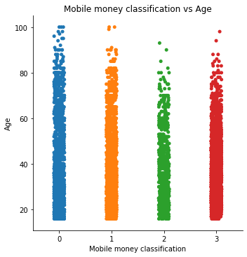

```python
sns.catplot(x ="mobile_money_classification", y="Q1", data=mobile_data);
plt.xlabel("Mobile money classification")
plt.ylabel("Age")
plt.title('Mobile money classification vs Age')
```

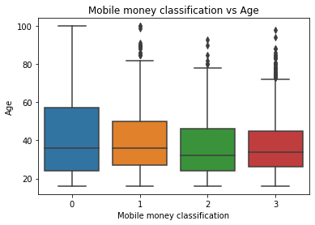

```python
sns.boxplot('mobile_money_classification', 'Q1', data=mobile_data)
plt.xlabel("Mobile money classification")
plt.ylabel("Age")
plt.title('Mobile money classification vs Age')
```

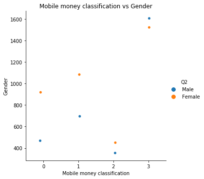

```python
gender__class_data = mobile_data.groupby(["mobile_money_classification", "Q2"]).size().reset_index(name="Count")
gender__class_data['Q2'] = gender__class_data['Q2'].replace({1: 'Male', 2: 'Female'})
sns.catplot(x ="mobile_money_classification", y="Count",hue = 'Q2',data =gender__class_data);
plt.xlabel("Mobile money classification")
plt.ylabel("Gender")
plt.title('Mobile money classification vs Gender')
```

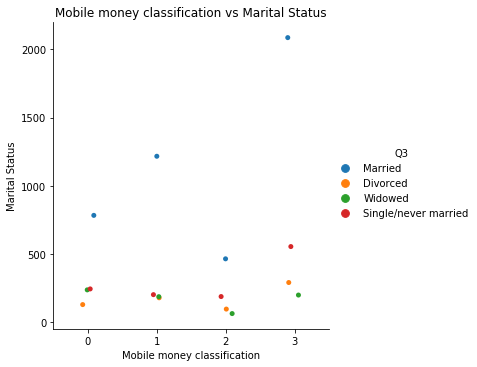

```python
marital_class_data = mobile_data.groupby(["mobile_money_classification", "Q3"]).size().reset_index(name="Count")
marital_class_data['Q3'] = marital_data['Q3'].replace({1: 'Married', 2: 'Divorced', 3:'Widowed',4:'Single/never married'})
sns.catplot(x ="mobile_money_classification", y="Count",hue = 'Q3',data = marital_class_data);
plt.xlabel("Mobile money classification")
plt.ylabel("Marital Status")
plt.title('Mobile money classification vs Marital Status')
```

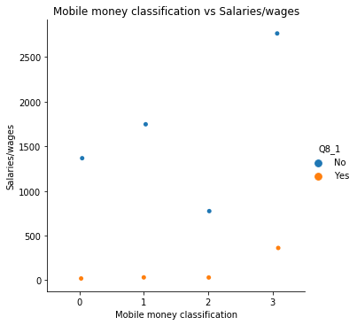

```python
income_class_data = mobile_data.groupby(["mobile_money_classification", "Q8_1"]).size().reset_index(name="Count")
income_class_data['Q8_1'] = income_data['Q8_1'].replace({0: 'No', 1: 'Yes'})
sns.catplot(x ="mobile_money_classification", y="Count",hue = 'Q8_1',data =income_class_data);
plt.xlabel("Mobile money classification")
plt.ylabel("Salaries/wages")
plt.title('Mobile money classification vs Salaries/wages')
```

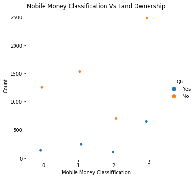

```python
land_class_data = mobile_data.groupby(["mobile_money_classification", "Q6"]).size().reset_index(name="Count")
land_class_data['Q6'] = land_data['Q6'].replace({1: 'Yes', 2: 'No'})
sns.catplot(x ="mobile_money_classification", y="Count",hue = 'Q6',data =land_class_data);
plt.xlabel("Mobile Money Classiffication")
plt.ylabel("Count")
plt.title('Mobile Money Classification Vs Land Ownership')
```